# assembly_analysis

### Effect of Kmer, MinCoverage and MinKmerCoverage on the maximum contig length in the assemblies

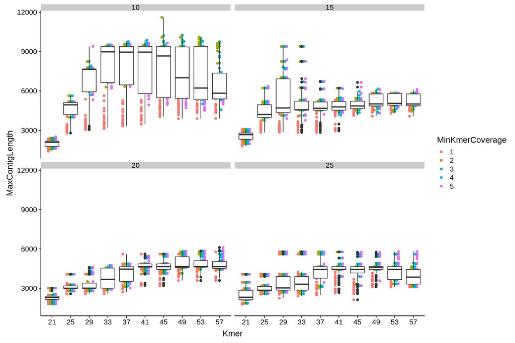

```r
ggplot(df, aes(x=Kmer, y=MaxContigLength)) + geom_point(aes(color=MinKmerCoverage), position=position_dodge(width=0.5) )  + geom_boxplot() + facet_wrap(~meancoverage)
```

### Effect of Bait mapped ratio between assembly and referenceseq

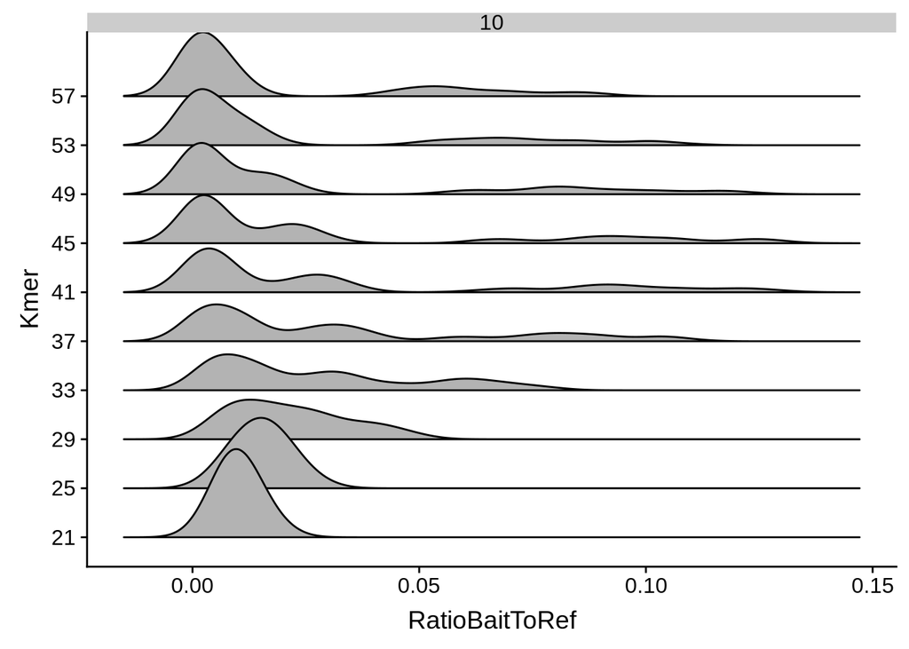

```r
ggplot(df, aes(RatioBaitToRef)) + geom_density_ridges2(aes(y=Kmer)) + facet_wrap(~Coverage)
```

The above plot shows the ratio of baits between assembly and the refseq.

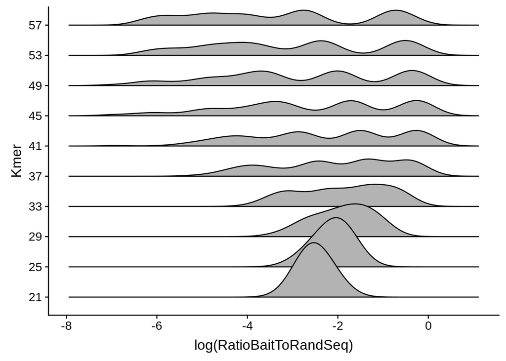

```r
ggplot(df, aes(x=log(RatioBaitToRandSeq))) + geom_density_ridges2(aes(y=Kmer))
```

The above plot shows the ratio of baits between assembly and random simulated sequence reads.

### How does minimum quality of simulated data affect number of assembly contigs

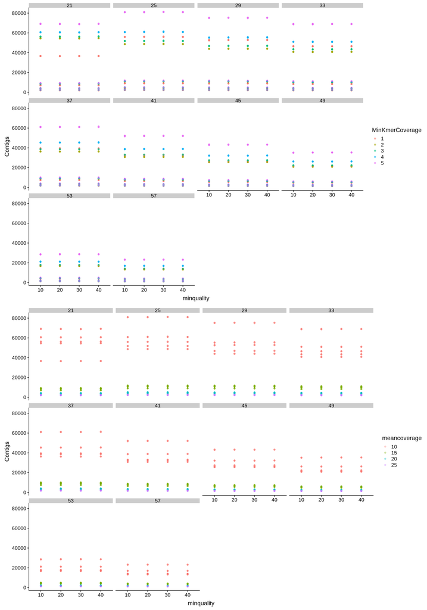

```r
plot1 <- ggplot(df, aes(minquality, Contigs)) + geom_point(aes(color=MinKmerCoverage), alpha=0.5) + facet_wrap(~Kmer)
plot2 <- ggplot(df, aes(minquality, Contigs)) + geom_point(aes(color=meancoverage),alpha=0.3) + facet_wrap(~Kmer)
plot_grid(plot1, plot2, ncol=1, nrow=2)
```

The above plot shows the number of contigs in the assembly when the data is simulated with different minimum quality.

### How does maximum insertions in simulated data affect number of assembly contigs

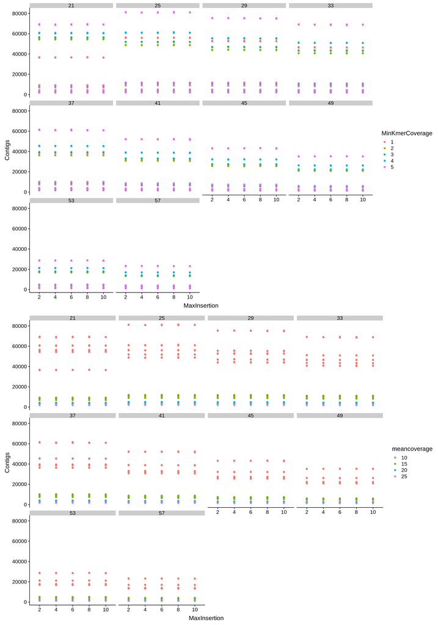

```r
plot1 <- ggplot(df, aes(MaxInsertion, Contigs)) + geom_point(aes(color=MinKmerCoverage)) + facet_wrap(~Kmer)
plot2 <- ggplot(df, aes(MaxInsertion, Contigs)) + geom_point(aes(color=meancoverage)) + facet_wrap(~Kmer)
plot_grid(plot1, plot2, ncol=1, nrow=2)
```

The above plot shows the number of contigs in the assembly when the data is simulated with different insertions.